# Author: Gyan Shashwat

# Project report : Development of Time series prediction model for Total Amperage Consumption of a machine.

```
<class 'pandas.core.frame.DataFrame'>
RangeIndex: 10000 entries, 0 to 9999
Data columns (total 10 columns):
 #   Column                  Non-Null Count  Dtype
---  ------                  --------------  -----
 0   time                    10000 non-null  datetime64[ns]
 1   MonthName               10000 non-null  object
 2   WeekDay                 10000 non-null  object
 3   WeekNumber              10000 non-null  int64
 4   phase_1_current_amp     10000 non-null  float64
 5   phase_2_current_amp     10000 non-null  float64
 6   phase_3_current_amp     10000 non-null  float64
 7   TotalCurrentAmperage    10000 non-null  float64
 8   AverageCurrentAmperage  10000 non-null  float64
 9   PowerStatus             10000 non-null  object
dtypes: datetime64[ns](1), float64(5), int64(1), object(3)
memory usage: 781.4+ KB
```

| time | MonthName | WeekDay | WeekNumber | phase_1_current_amp | phase_2_current_amp | phase_3_current_amp | TotalCurrentAmperage | AverageCurrentAmperage | PowerStatus |
| --- | --- | --- | --- | --- | --- | --- | --- | --- | --- |
| 2023-11-17 07:35:52 | November | Friday | 46 | 10.281491 | 11.570706 | 10.984953 | 32.837150 | 10.945717 | On |
| 2023-11-17 07:36:22 | November | Friday | 46 | 10.506440 | 11.650215 | 10.933455 | 33.090110 | 11.030037 | On |
| 2023-11-17 07:50:12 | November | Friday | 46 | 10.573857 | 12.088927 | 10.978826 | 33.641610 | 11.213870 | On |
| 2023-11-17 07:50:42 | November | Friday | 46 | 10.298803 | 11.997374 | 10.799131 | 33.095308 | 11.031769 | On |
| 2023-11-17 07:51:12 | November | Friday | 46 | 10.248630 | 11.768479 | 10.787249 | 32.804358 | 10.934786 | On |
| ... | ... | ... | ... | ... | ... | ... | ... | ... | ... |
| 2023-11-21 16:44:36 | November | Tuesday | 47 | 1.032101 | 1.207038 | 1.136952 | 3.376092 | 1.125364 | Off |
| 2023-11-21 16:45:01 | November | Tuesday | 47 | 1.033842 | 1.200865 | 1.135421 | 3.370128 | 1.123376 | Off |
| 2023-11-21 16:45:26 | November | Tuesday | 47 | 1.026253 | 1.204462 | 1.132380 | 3.363096 | 1.121032 | Off |
| 2023-11-21 16:45:50 | November | Tuesday | 47 | 1.033262 | 1.201701 | 1.136604 | 3.371567 | 1.123856 | Off |
| 2023-11-21 16:46:13 | November | Tuesday | 47 | 1.030732 | 1.204300 | 1.139366 | 3.374398 | 1.124799 | Off |

10000 rows × 9 columns

```
MonthName                    1
WeekDay                      5
WeekNumber                   2
phase_1_current_amp       5173
phase_2_current_amp       4476
phase_3_current_amp       5152
TotalCurrentAmperage      9073
AverageCurrentAmperage    9073
PowerStatus                  2
dtype: int64
```

### The data is only for one month, it shows less variance in a time series data

# Data Visulization and EDA

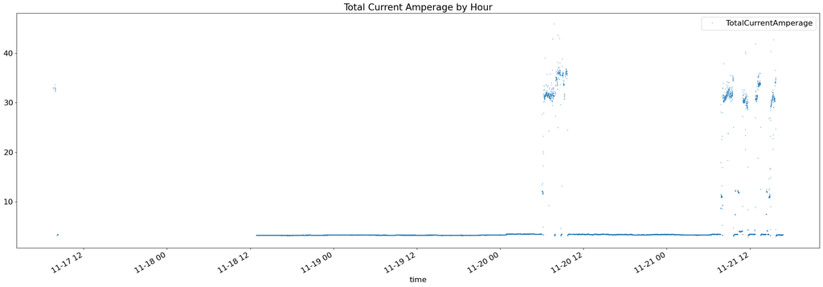

### This plot elaborates the value of TotalCurrentAmperage are highly unbalanced with respect to date and have less varince.

```
count    10000.000000
mean         6.092420
std          8.362587
min          2.796372
25%          3.265642
50%          3.308025
75%          3.430914
max         45.887653
Name: TotalCurrentAmperage, dtype: float64
```

### The stastical discription of the response variable shows even third quantile values (75 percent of values are less than 3.43), therefore 45 can be considered as outlier but the above plot shows a lot of scatters which is more than considers to be an outlier, thereffore more analysis is required.

|  | WeekNumber | phase_1_current_amp | phase_2_current_amp | phase_3_current_amp | TotalCurrentAmperage | AverageCurrentAmperage |
| --- | --- | --- | --- | --- | --- | --- |
| WeekNumber | 1.000000 | 0.128157 | 0.126688 | 0.127739 | 0.127557 | 0.127557 |
| phase_1_current_amp | 0.128157 | 1.000000 | 0.998758 | 0.997536 | 0.999262 | 0.999262 |
| phase_2_current_amp | 0.126688 | 0.998758 | 1.000000 | 0.998810 | 0.999754 | 0.999754 |
| phase_3_current_amp | 0.127739 | 0.997536 | 0.998810 | 1.000000 | 0.999349 | 0.999349 |
| TotalCurrentAmperage | 0.127557 | 0.999262 | 0.999754 | 0.999349 | 1.000000 | 1.000000 |
| AverageCurrentAmperage | 0.127557 | 0.999262 | 0.999754 | 0.999349 | 1.000000 | 1.000000 |

- The correlation within phase1, phase2, phase3 and Average Current Amperage is very high, therefore we can use any one of them.
- All of these X variables are highly correlated with the response variable (TotalCurrentAmperage), but I am assuming to use the time series model in real time the user will only provide date range and power status of the machine on respective dates.

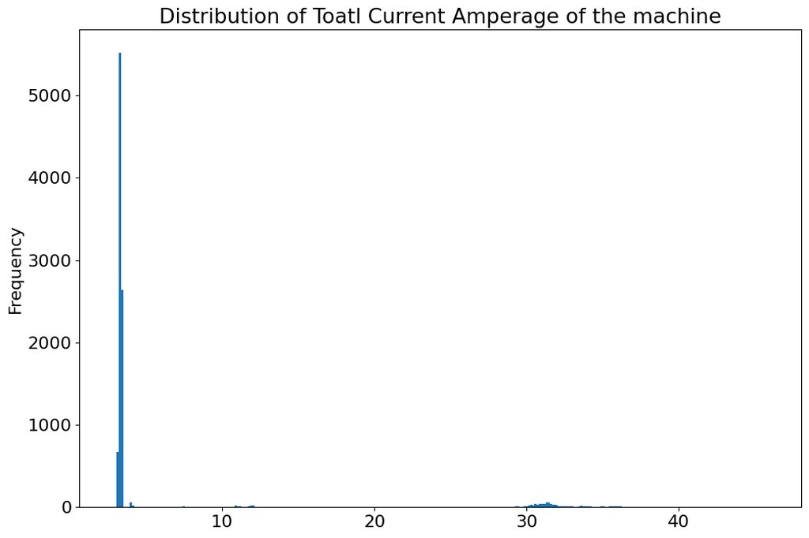

- This distribution plot shows an exponetial plot, and skewed. This will require transformation for getting a uniform distribution

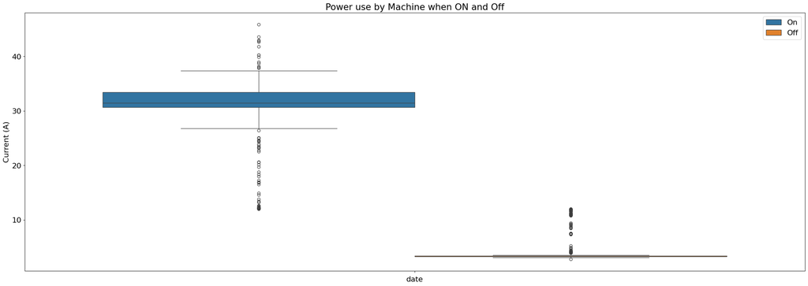

### This plot concludes that power status is one of the most important factor for the prediction of Amperage usage by the machine. The distinctive pattern in the data points based of power status of the machine will help the model to predict closer to the actual values.

### This also help us to undestand the 25 percent of data points above 3.4 is also significant and can not be considered as outliers.

# Feature Engineering

### Creating Power status code

Transforming Power status into numeric value as it is a significant variable (factor) in predicting ampere usage and shows a distinctive data pattern.

- Off (0)
- On (1)

Checking the correlation for power status code with the response variable (TotalAmpereUsage)

|  | WeekNumber | phase_1_current_amp | phase_2_current_amp | phase_3_current_amp | TotalCurrentAmperage | AverageCurrentAmperage | PowerStatusCode |
| --- | --- | --- | --- | --- | --- | --- | --- |
| WeekNumber | 1.000000 | 0.128157 | 0.126688 | 0.127739 | 0.127557 | 0.127557 | 0.122366 |
| phase_1_current_amp | 0.128157 | 1.000000 | 0.998758 | 0.997536 | 0.999262 | 0.999262 | 0.979093 |
| phase_2_current_amp | 0.126688 | 0.998758 | 1.000000 | 0.998810 | 0.999754 | 0.999754 | 0.980278 |
| phase_3_current_amp | 0.127739 | 0.997536 | 0.998810 | 1.000000 | 0.999349 | 0.999349 | 0.979866 |
| TotalCurrentAmperage | 0.127557 | 0.999262 | 0.999754 | 0.999349 | 1.000000 | 1.000000 | 0.980299 |
| AverageCurrentAmperage | 0.127557 | 0.999262 | 0.999754 | 0.999349 | 1.000000 | 1.000000 | 0.980299 |
| PowerStatusCode | 0.122366 | 0.979093 | 0.980278 | 0.979866 | 0.980299 | 0.980299 | 1.000000 |

Power status code is higly correlated with the response variable. Therefore it is siginificant categorical variable to predict the usage.

### Creating time series feature

```
<class 'pandas.core.frame.DataFrame'>
DatetimeIndex: 10000 entries, 2023-11-17 07:35:52 to 2023-11-21 16:46:13
Data columns (total 19 columns):
 #   Column                  Non-Null Count  Dtype
---  ------                  --------------  -----
 0   MonthName               10000 non-null  object
 1   WeekDay                 10000 non-null  object
 2   WeekNumber              10000 non-null  UInt32
 3   phase_1_current_amp     10000 non-null  float64
 4   phase_2_current_amp     10000 non-null  float64
 5   phase_3_current_amp     10000 non-null  float64
 6   TotalCurrentAmperage    10000 non-null  float64
 7   AverageCurrentAmperage  10000 non-null  float64
 8   PowerStatus             10000 non-null  object
 9   PowerStatusCode         10000 non-null  int64
 10  date                    10000 non-null  datetime64[ns]
 11  hour                    10000 non-null  int32
 12  dayofweek               10000 non-null  int32
 13  year                    10000 non-null  int32
 14  dayofyear               10000 non-null  int32
 15  quarter                 10000 non-null  int32
 16  dayofmonth              10000 non-null  int32
 17  date_offset             10000 non-null  int32
 18  season                  10000 non-null  category
dtypes: UInt32(1), category(1), datetime64[ns](1), float64(5), int32(7), int64(1), object(3)
memory usage: 1.2+ MB
```

|  | WeekNumber | phase_1_current_amp | phase_2_current_amp | phase_3_current_amp | TotalCurrentAmperage | AverageCurrentAmperage | hour | dayofweek | year | dayofyear | quarter | dayofmonth | date_offset |
| --- | --- | --- | --- | --- | --- | --- | --- | --- | --- | --- | --- | --- | --- |
| WeekNumber | 1.000000 | 0.296621 | 0.291722 | 0.293026 | 0.293816 | 0.293816 | -0.239738 | -0.982779 | NaN | 0.873039 | NaN | 0.873039 | 0.873039 |
| phase_1_current_amp | 0.296621 | 1.000000 | 0.998758 | 0.997536 | 0.999262 | 0.999262 | -0.106079 | -0.273269 | NaN | 0.307106 | NaN | 0.307106 | 0.307106 |
| phase_2_current_amp | 0.291722 | 0.998758 | 1.000000 | 0.998810 | 0.999754 | 0.999754 | -0.102944 | -0.267572 | NaN | 0.305159 | NaN | 0.305159 | 0.305159 |
| phase_3_current_amp | 0.293026 | 0.997536 | 0.998810 | 1.000000 | 0.999349 | 0.999349 | -0.103170 | -0.268739 | NaN | 0.306598 | NaN | 0.306598 | 0.306598 |
| TotalCurrentAmperage | 0.293816 | 0.999262 | 0.999754 | 0.999349 | 1.000000 | 1.000000 | -0.104036 | -0.269852 | NaN | 0.306400 | NaN | 0.306400 | 0.306400 |
| AverageCurrentAmperage | 0.293816 | 0.999262 | 0.999754 | 0.999349 | 1.000000 | 1.000000 | -0.104036 | -0.269852 | NaN | 0.306400 | NaN | 0.306400 | 0.306400 |
| hour | -0.239738 | -0.106079 | -0.102944 | -0.103170 | -0.104036 | -0.104036 | 1.000000 | 0.171057 | NaN | -0.379655 | NaN | -0.379655 | -0.379655 |
| dayofweek | -0.982779 | -0.273269 | -0.267572 | -0.268739 | -0.269852 | -0.269852 | 0.171057 | 1.000000 | NaN | -0.767892 | NaN | -0.767892 | -0.767892 |
| year | NaN | NaN | NaN | NaN | NaN | NaN | NaN | NaN | NaN | NaN | NaN | NaN | NaN |
| dayofyear | 0.873039 | 0.307106 | 0.305159 | 0.306598 | 0.306400 | 0.306400 | -0.379655 | -0.767892 | NaN | 1.000000 | NaN | 1.000000 | 1.000000 |
| quarter | NaN | NaN | NaN | NaN | NaN | NaN | NaN | NaN | NaN | NaN | NaN | NaN | NaN |
| dayofmonth | 0.873039 | 0.307106 | 0.305159 | 0.306598 | 0.306400 | 0.306400 | -0.379655 | -0.767892 | NaN | 1.000000 | NaN | 1.000000 | 1.000000 |
| date_offset | 0.873039 | 0.307106 | 0.305159 | 0.306598 | 0.306400 | 0.306400 | -0.379655 | -0.767892 | NaN | 1.000000 | NaN | 1.000000 | 1.000000 |

```
<IntegerArray>
[46, 47]
Length: 2, dtype: UInt32
```

### Significant variables to predict the Total current usage.

- The Week Number, day of week, day of year, day of month and day_offset has more than 0.20 correlation with the response variable. Though the day of year, day of month and day_offset has same correlation, therefore we can take any one of them as a factor.
- The other variables like phase1, phase2, phase3 and AverageCurrentAmperage are highle correlated but I am assuming the prediction of Total Amperage usage will be based on only dates and power status of the machine in real time as the Total Amperage Usage is the sum of phase1, phase2, phase3. Therefore, I will discard them as x variables for the prediction.

### Distribution transformation of the response variable

- Earlier in the data visualisation we saw the distribution of the TotalCurrentUsage that the distribution is skewed and exponetial in nature. Therefore, we will apply log transform of the distribution to be more uniform and then we will check the correlation of x variable with the response variable.

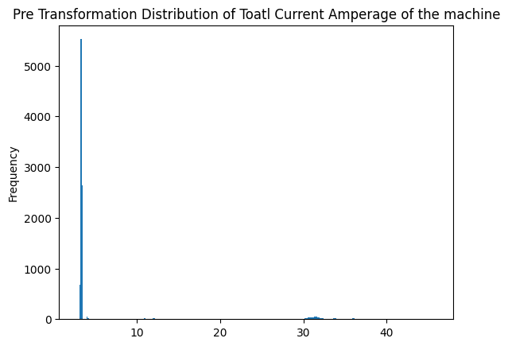

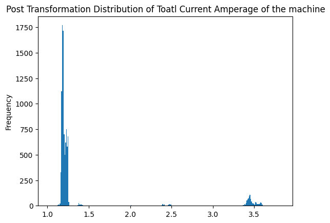

### Post Feature EDA and Initial ML analysis

|  | WeekNumber | phase_1_current_amp | phase_2_current_amp | phase_3_current_amp | TotalCurrentAmperage | AverageCurrentAmperage | hour | dayofweek | year | dayofyear | quarter | dayofmonth | date_offset | TransformedTotalCurrentAmperage |
| --- | --- | --- | --- | --- | --- | --- | --- | --- | --- | --- | --- | --- | --- | --- |
| WeekNumber | 1.000000 | 0.296621 | 0.291722 | 0.293026 | 0.293816 | 0.293816 | -0.239738 | -0.982779 | NaN | 0.873039 | NaN | 0.873039 | 0.873039 | 0.322566 |
| phase_1_current_amp | 0.296621 | 1.000000 | 0.998758 | 0.997536 | 0.999262 | 0.999262 | -0.106079 | -0.273269 | NaN | 0.307106 | NaN | 0.307106 | 0.307106 | 0.990910 |
| phase_2_current_amp | 0.291722 | 0.998758 | 1.000000 | 0.998810 | 0.999754 | 0.999754 | -0.102944 | -0.267572 | NaN | 0.305159 | NaN | 0.305159 | 0.305159 | 0.992978 |
| phase_3_current_amp | 0.293026 | 0.997536 | 0.998810 | 1.000000 | 0.999349 | 0.999349 | -0.103170 | -0.268739 | NaN | 0.306598 | NaN | 0.306598 | 0.306598 | 0.991191 |
| TotalCurrentAmperage | 0.293816 | 0.999262 | 0.999754 | 0.999349 | 1.000000 | 1.000000 | -0.104036 | -0.269852 | NaN | 0.306400 | NaN | 0.306400 | 0.306400 | 0.992275 |
| AverageCurrentAmperage | 0.293816 | 0.999262 | 0.999754 | 0.999349 | 1.000000 | 1.000000 | -0.104036 | -0.269852 | NaN | 0.306400 | NaN | 0.306400 | 0.306400 | 0.992275 |
| hour | -0.239738 | -0.106079 | -0.102944 | -0.103170 | -0.104036 | -0.104036 | 1.000000 | 0.171057 | NaN | -0.379655 | NaN | -0.379655 | -0.379655 | -0.112538 |
| dayofweek | -0.982779 | -0.273269 | -0.267572 | -0.268739 | -0.269852 | -0.269852 | 0.171057 | 1.000000 | NaN | -0.767892 | NaN | -0.767892 | -0.767892 | -0.295534 |
| year | NaN | NaN | NaN | NaN | NaN | NaN | NaN | NaN | NaN | NaN | NaN | NaN | NaN | NaN |
| dayofyear | 0.873039 | 0.307106 | 0.305159 | 0.306598 | 0.306400 | 0.306400 | -0.379655 | -0.767892 | NaN | 1.000000 | NaN | 1.000000 | 1.000000 | 0.338292 |
| quarter | NaN | NaN | NaN | NaN | NaN | NaN | NaN | NaN | NaN | NaN | NaN | NaN | NaN | NaN |
| dayofmonth | 0.873039 | 0.307106 | 0.305159 | 0.306598 | 0.306400 | 0.306400 | -0.379655 | -0.767892 | NaN | 1.000000 | NaN | 1.000000 | 1.000000 | 0.338292 |
| date_offset | 0.873039 | 0.307106 | 0.305159 | 0.306598 | 0.306400 | 0.306400 | -0.379655 | -0.767892 | NaN | 1.000000 | NaN | 1.000000 | 1.000000 | 0.338292 |
| TransformedTotalCurrentAmperage | 0.322566 | 0.990910 | 0.992978 | 0.991191 | 0.992275 | 0.992275 | -0.112538 | -0.295534 | NaN | 0.338292 | NaN | 0.338292 | 0.338292 | 1.000000 |

- The correlation with the transformed value of response variable and x variables is higher than the non transformed response variable. We will use a initial ML model to determine the prediction error for both the response variable.

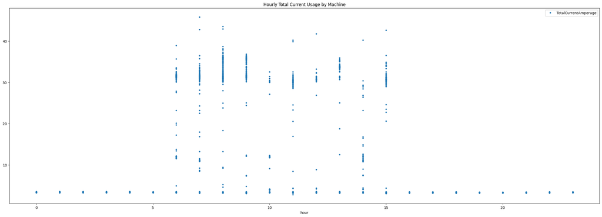

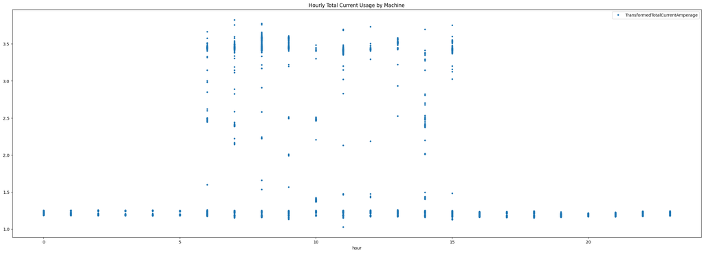

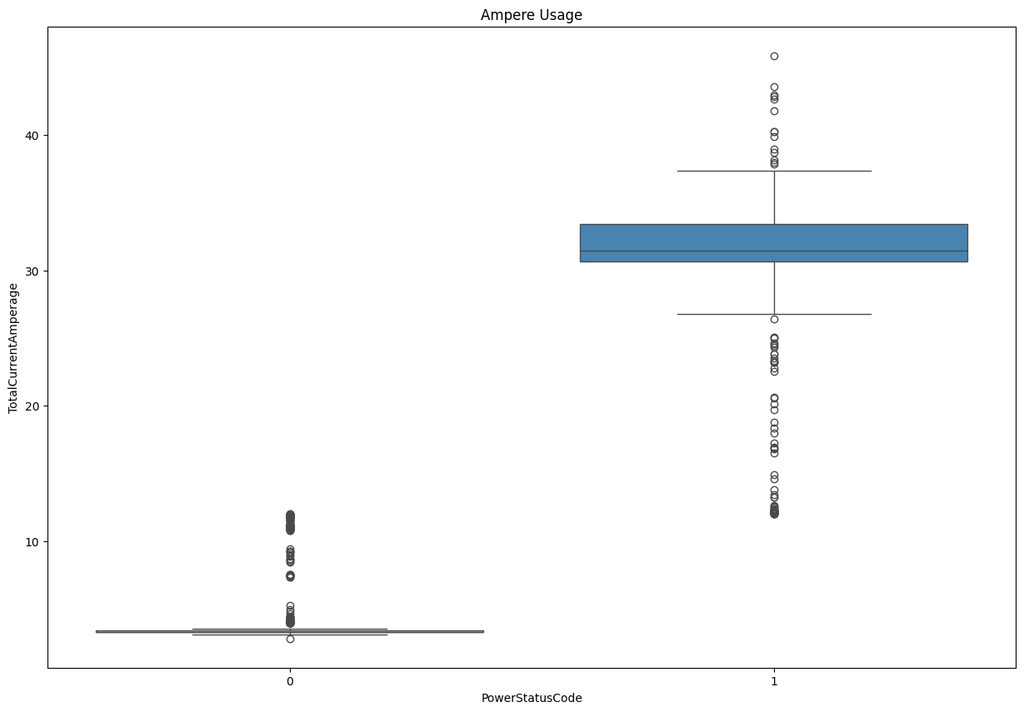

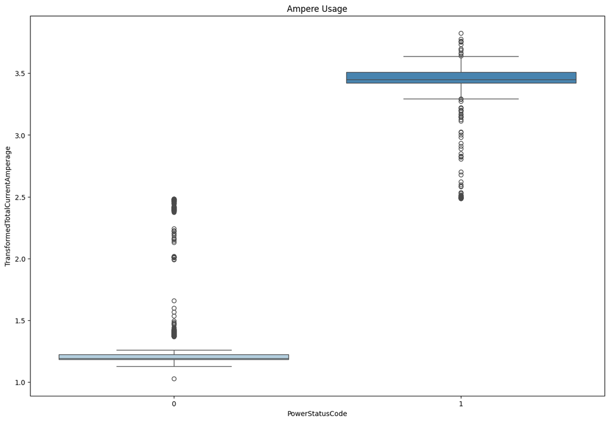

- The above plots and correlation table shows change in the correlation value in distribution of the data points from pre and post transformed data.
- Let's check what diffrence it brings in prediction by an initial ML model on using both pre and post transformed response variable.

### Linear regression model.

- Taking the significant variable and divide them in train and test data.

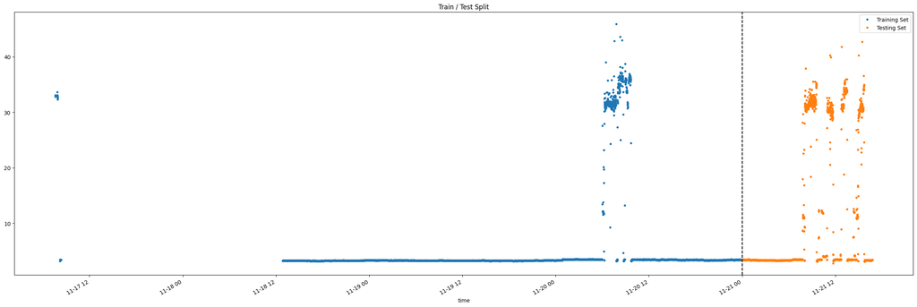

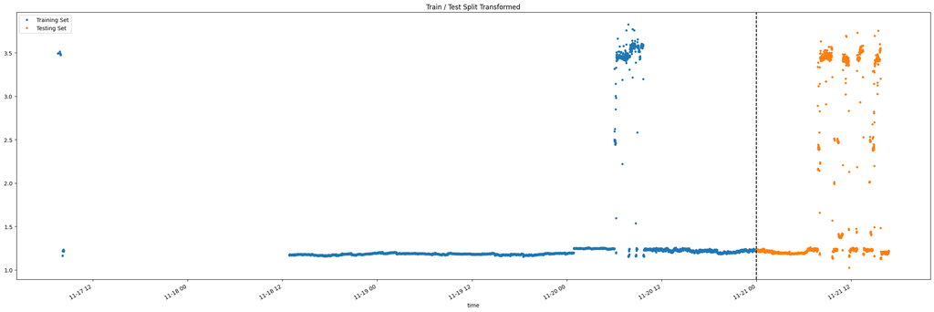

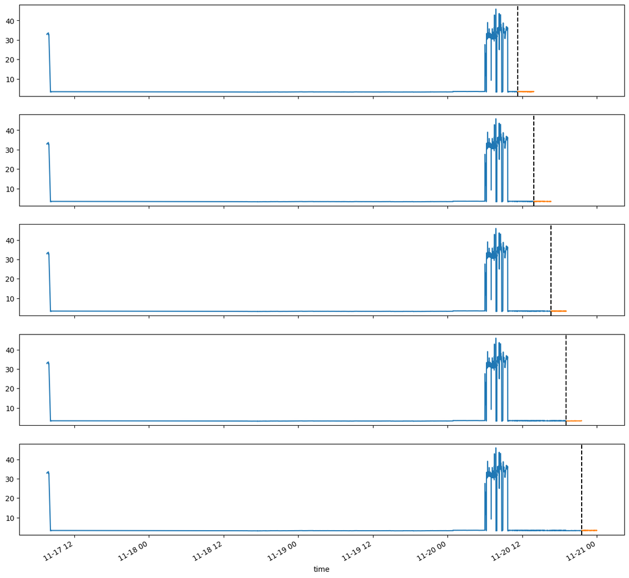

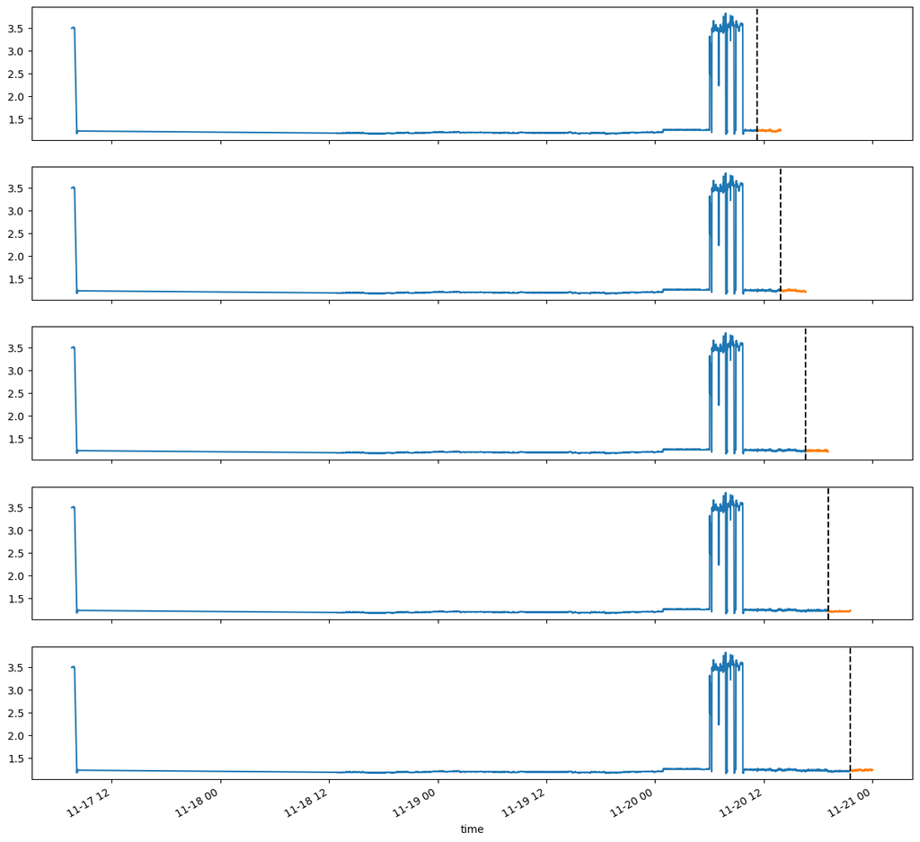

```
LinearRegression()
```

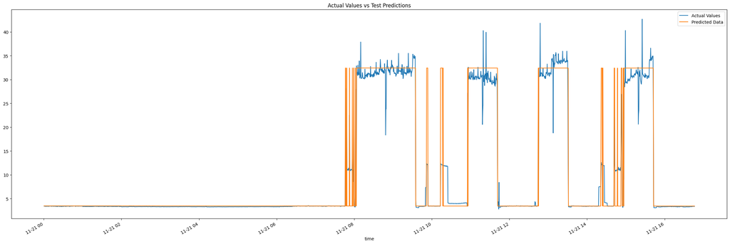

[output not shown]

```
MAPE Score on test set: 8.55
```

```
LinearRegression()
```

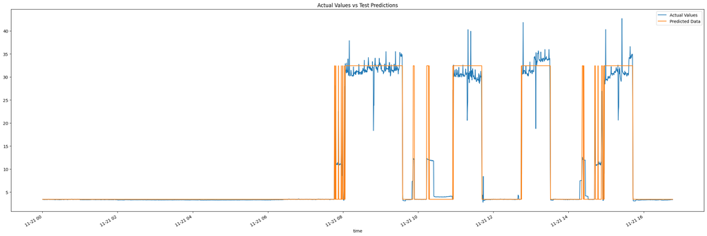

```
MAPE Score on train set: 0.00
```

```
MAPE Score on test set: 8.31
```

### With transformed response variable.

```
LinearRegression()
```

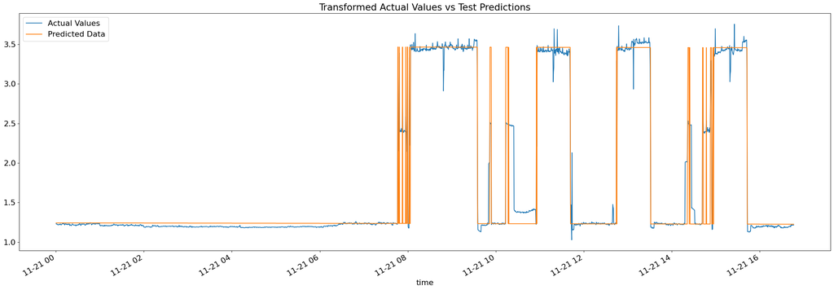

```
MAPE Score on train set: 0.95
```

```
MAPE Score on test set: 4.64
```

```
LinearRegression()
```

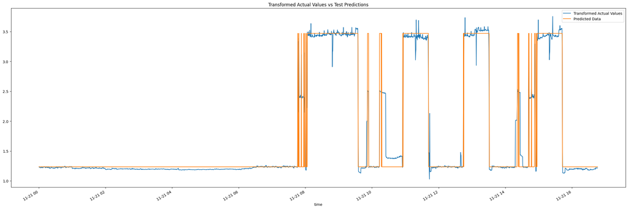

```
MAPE Score on train set: 0.00
```

```
MAPE Score on test set: 4.55
```

### Selecting most significant x and response variable

| Model Names | Training Scores | Testing Scores |
| --- | --- | --- |
| Linear Regression Model with hour x variable | 1.636133 | 8.545395 |
| Linear Regression Model without hour as x variable | 0.000000 | 8.307741 |
| Transformed Linear Regression Model with hour x variable | 0.948260 | 4.639980 |
| Transformed Linear Regression Model without hour as x variable | 0.000000 | 4.547847 |

# Model Selection

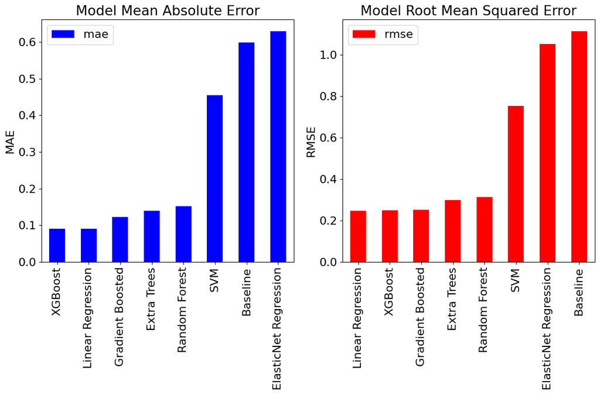

|  | mae | rmse |
| --- | --- | --- |
| Linear Regression | 0.090551 | 0.247004 |
| ElasticNet Regression | 0.629783 | 1.050794 |
| Random Forest | 0.151615 | 0.313657 |
| Extra Trees | 0.140009 | 0.297514 |
| SVM | 0.454641 | 0.752122 |
| Gradient Boosted | 0.122851 | 0.250963 |
| XGBoost | 0.090472 | 0.249603 |
| Baseline | 0.598817 | 1.112821 |

```
>lr 0.982 (0.009)
>en 0.017 (0.003)
>rf 0.989 (0.005)
>SVM 0.961 (0.009)
>Extra Trees 0.989 (0.005)
>Gradient Boost 0.970 (0.007)
>XGBoost 0.981 (0.008)
```

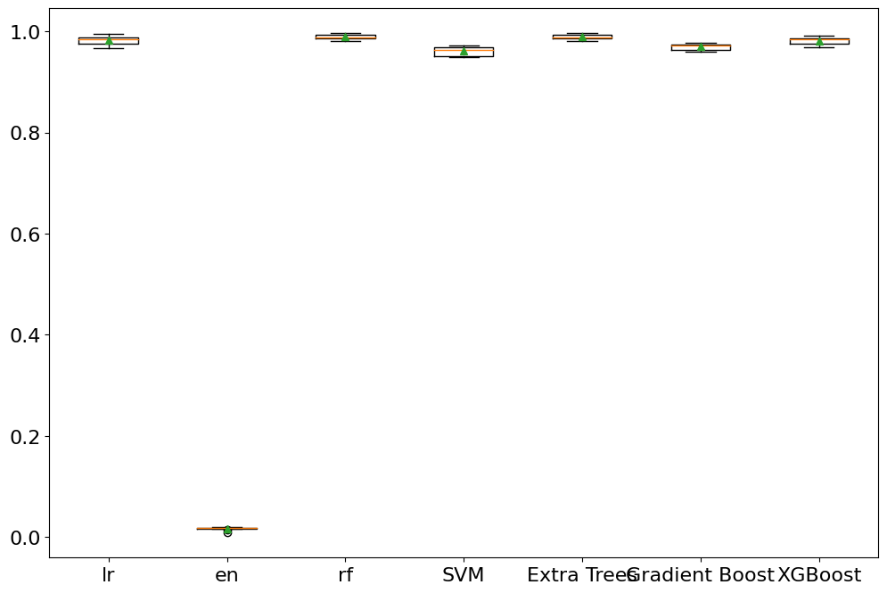

```
>lr -0.015 (0.002)
>en -0.214 (0.013)
>rf -0.010 (0.001)
>SVM -0.081 (0.002)
>Extra Trees -0.010 (0.001)
>Gradient Boost -0.032 (0.002)
>XGBoost -0.028 (0.002)
```

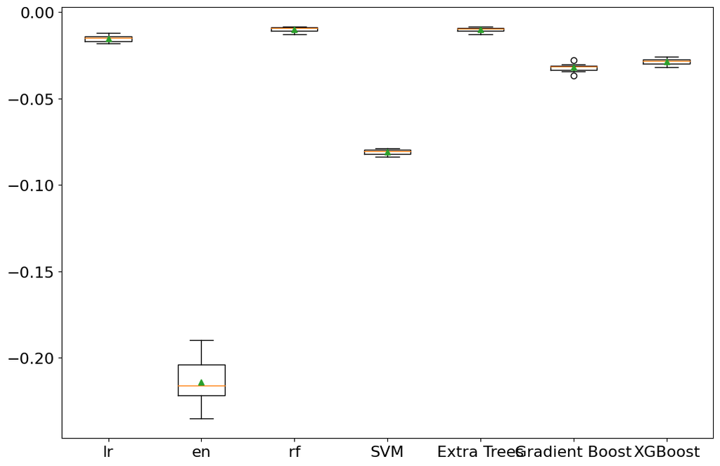

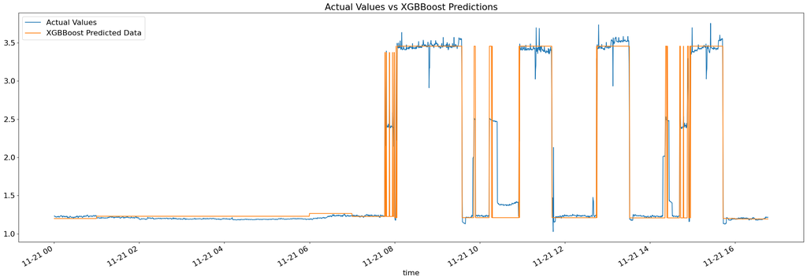

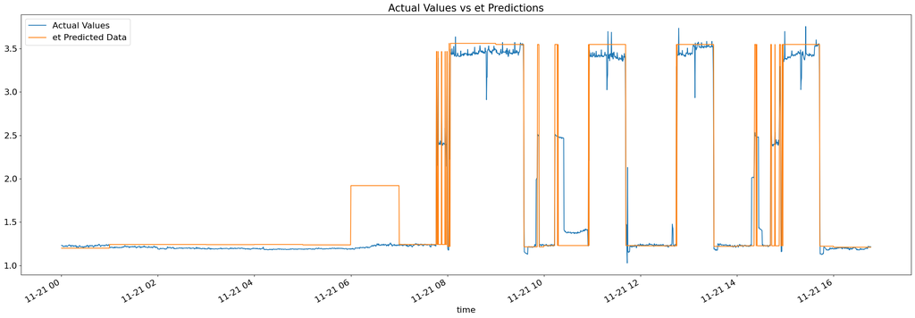

```
MAPE Score on train set: 1.90
```

```
MAPE Score on test set: 4.63
```

```
Et MAPE Score on train set: 0.58
```

```
ET MAPE Score on test set: 8.47
```

| Model Names | Training Scores | Testing Scores |
| --- | --- | --- |
| Linear Regression Model with hour x variable | 1.636133 | 8.545395 |
| Linear Regression Model without hour as x variable | 0.000000 | 8.307741 |
| Transformed Linear Regression Model with hour x variable | 0.948260 | 4.639980 |
| Transformed Linear Regression Model without hour as x variable | 0.000000 | 4.547847 |
| XGBoost Model | 1.898350 | 4.626369 |
| ET Model | 0.575077 | 8.466950 |

# Conclusion

- After doing all model selection analysis, we should select XGBoost model as our final model with the R-squared value of 0.981, negative mean absolute error of 0.028 and less overfit than the other top peforming models like extra tree or random forest based on k-fold cross validation.

## Save and Export Model

# Learned Feature Importance

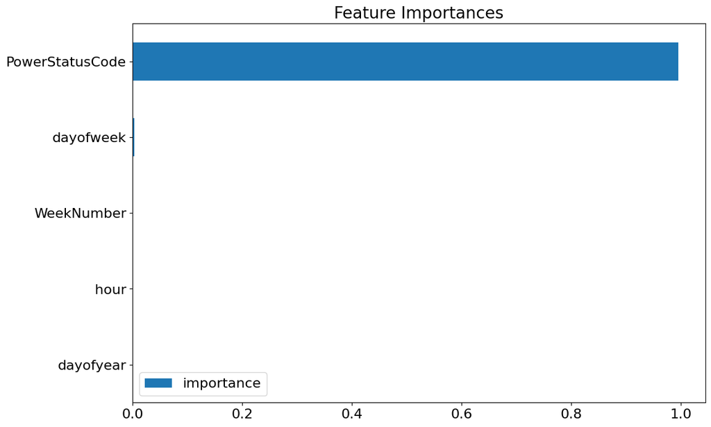

## Future Prediction

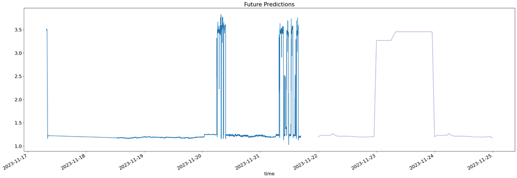

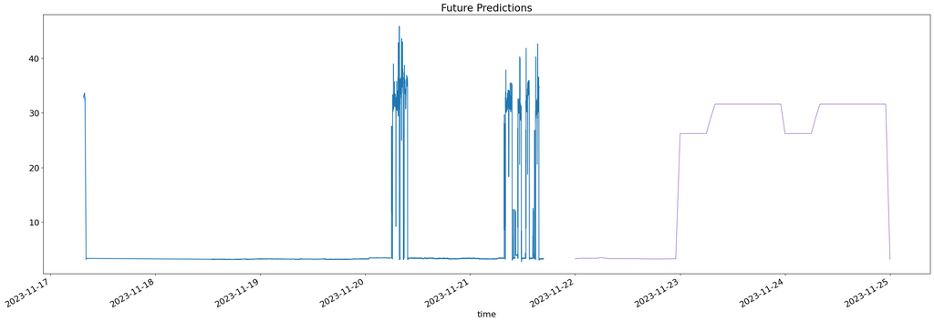

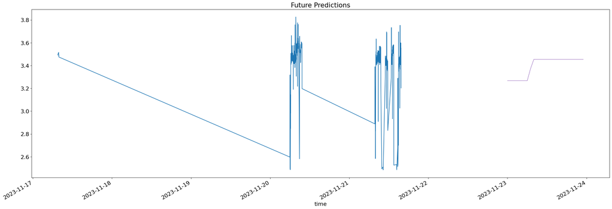

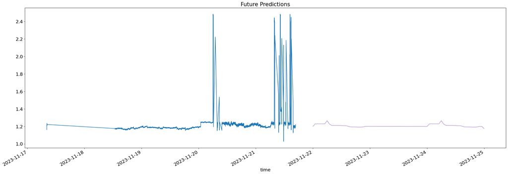

# Final Coclusion

# Working Proof of concept

- I have created a small proof of concept for the time series prediction model, with the model traind and saved. The POC is also shared with this report.

```
[NbConvertApp] Converting notebook /content/drive/MyDrive/Colab_Notebooks/Time_Series_Power_Consumption_Analysis.ipynb to html
[NbConvertApp] Writing 3303771 bytes to /content/drive/MyDrive/Colab_Notebooks/Time_Series_Power_Consumption_Analysis.html
```